# AREE Proteomics Workflow Report

TIMMINS2014_OA_GILL / pco2_2800_vs_400

## Run summary

- **Study**: TIMMINS2014_OA_GILL
- **Comparison**: pco2_2800_vs_400
- **Mode**: raw_reanalysis
- **Workflow version**: 0.1.0-scaffold
- **Date generated**: 2026-10-17T12:03:55.774510-07:00
- **Provenance level**: infra-level (see docs/design.md section 4; distinct from per-row evidence-level provenance)

No warnings recorded for this run.

## QC metrics

| metric | value |
| --- | --- |
| n_proteins | 639 |
| mean_missingness_percent | 4.83176838810642 |

limma on 4 control vs 4 treatment samples: 639 of 1616 proteins tested (detected in at least 3 samples per arm), 0 at padj < 0.05. Not tested: detected_too_rarely_in_both_arms 585; detected_too_rarely_in_control 125; detected_too_rarely_in_treatment 90; not_detected 177.

## Missingness distribution

Per-protein `missingness_percent` from the standardized evidence-ready table. Values of `NA` indicate the source study/mode did not report missingness (this is left explicit, not imputed as zero, per docs/design.md section 4).

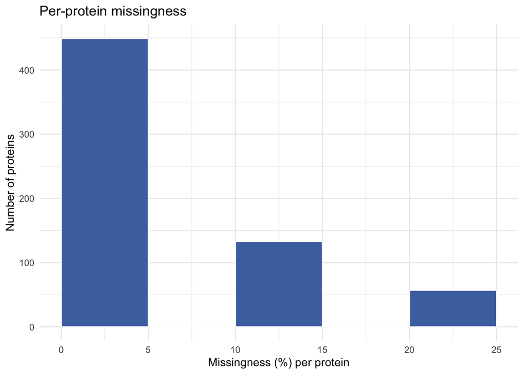

## Volcano plot

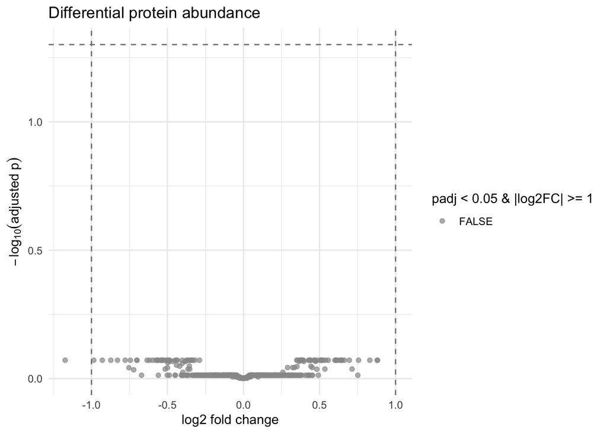

| protein_accession | gene_symbol | log2FC | lfcSE | pvalue | padj | missingness_percent | analysis_method |
| --- | --- | --- | --- | --- | --- | --- | --- |
| CGI_10000041 | CGI_10000041 | -0.7001940 | 0.3752920 | 0.0887515 | 0.8479324 | 0.0 | spectral_count_limma_moderated_t |
| CGI_10001170 | LOC105338756 | 0.6490024 | 0.3211254 | 0.0681062 | 0.8479324 | 0.0 | spectral_count_limma_moderated_t |
| CGI_10001348 | LOC105324454 | -0.5672440 | 0.2360683 | 0.0369449 | 0.8479324 | 12.5 | spectral_count_limma_moderated_t |
| CGI_10001478 | LOC105342925 | 0.6419264 | 0.2938652 | 0.0564984 | 0.8479324 | 25.0 | spectral_count_limma_moderated_t |
| CGI_10001554 | CGI_10001554 | 0.5256462 | 0.2296857 | 0.0449236 | 0.8479324 | 12.5 | spectral_count_limma_moderated_t |
| CGI_10002594 | LOC105334510 | -0.7783326 | 0.3473634 | 0.0515273 | 0.8479324 | 25.0 | spectral_count_limma_moderated_t |
| CGI_10002799 | LOC105341025 | -0.5224199 | 0.2278574 | 0.0473097 | 0.8479324 | 25.0 | spectral_count_limma_moderated_t |
| CGI_10002812 | LOC105327141 | -0.3395925 | 0.1735107 | 0.0759848 | 0.8479324 | 0.0 | spectral_count_limma_moderated_t |
| CGI_10002917 | LOC105333281 | 0.8819243 | 0.3494398 | 0.0300165 | 0.8479324 | 12.5 | spectral_count_limma_moderated_t |
| CGI_10003897 | CGI_10003897 | -0.3190370 | 0.1765700 | 0.0979824 | 0.8479324 | 0.0 | spectral_count_limma_moderated_t |
| CGI_10004156 | LOC105347124 | -0.7440686 | 0.2749202 | 0.0239461 | 0.8479324 | 25.0 | spectral_count_limma_moderated_t |
| CGI_10004346 | LOC105342582 | -0.3580835 | 0.2006675 | 0.1017178 | 0.8479324 | 0.0 | spectral_count_limma_moderated_t |
| CGI_10005381 | LOC105328728 | -0.4357314 | 0.1981444 | 0.0499944 | 0.8479324 | 0.0 | spectral_count_limma_moderated_t |
| CGI_10006964 | CGI_10006964 | 0.5126060 | 0.2453138 | 0.0629486 | 0.8479324 | 12.5 | spectral_count_limma_moderated_t |
| CGI_10007057 | CGI_10007057 | 0.4373296 | 0.2424514 | 0.1011802 | 0.8479324 | 12.5 | spectral_count_limma_moderated_t |
| CGI_10007570 | LOC105342358 | -0.8729843 | 0.4407777 | 0.0730070 | 0.8479324 | 0.0 | spectral_count_limma_moderated_t |
| CGI_10007607 | CGI_10007607 | -1.1731864 | 0.2762764 | 0.0021100 | 0.8479324 | 25.0 | spectral_count_limma_moderated_t |
| CGI_10007733 | CGI_10007733 | -0.9286413 | 0.2437740 | 0.0040881 | 0.8479324 | 25.0 | spectral_count_limma_moderated_t |
| CGI_10007862 | LOC105325218 | 0.6072152 | 0.2380284 | 0.0286447 | 0.8479324 | 12.5 | spectral_count_limma_moderated_t |
| CGI_10008733 | LOC105318227 | -0.5975465 | 0.1913996 | 0.0096345 | 0.8479324 | 0.0 | spectral_count_limma_moderated_t |

## Reproducibility

```
List of 16
 $ workflow_name                 : chr "aree/workflows/proteomics"
 $ workflow_version              : chr "0.1.0-scaffold"
 $ mode                          : chr "raw_reanalysis"
 $ study_id                      : chr "TIMMINS2014_OA_GILL"
 $ comparison_id                 : chr "pco2_2800_vs_400"
 $ date_generated                : chr "2026-10-17T12:03:55.774510-07:00"
 $ generated_by                  : chr "automated:aree-proteomics-workflow@0.1.0-scaffold"
 $ provenance_level              : chr "infra-level (see docs/design.md section 4; distinct from per-row evidence-level provenance)"
 $ inputs                        :List of 2
 $ parameters                    :List of 2
 $ software_versions             :List of 7
 $ software_versions_not_captured:List of 1
 $ container_engine              : NULL
 $ qc_metrics                    :List of 3
 $ missingness_summary           :List of 7
 $ warnings                      : list()
```

This report was generated from TIMMINS2014_OA_GILL_pco2_2800_vs_400_protein_abundance_standardized.tsv and TIMMINS2014_OA_GILL_pco2_2800_vs_400_manifest.json by the AREE proteomics workflow scaffold. It is intended to accompany, not replace, the standardized TSV as the machine-readable artifact consumed by `aree harmonize`.